# A simple introduction to statistical test and statistical significance

Damien Dupre, Ph.D.  
12/09/2018

### Why statistics?

[figure not shown]

At work, each task involves … taking decisions

Decisions must be based on **rational arguments and numbers** rather than on **opinions and intuitions**

### Do we really need statistics?

Advantage of decision making process based on numbers:

- Helps to convince doubtful colleagues
- Can be blamed in case something goes wrong

So yes, we really **need** statistics!

### Example in context

Imagine you are working at Apple Inc. in the product dev. department

- You are working on the new iPhone prototype
- Your manager is asking you if the prototype is ready to be launched to the market (decision to be made)
- Your answer is *“if the new prototype has more user satisfaction than the current iPhone we can launch it”*

How to compare the new prototype with the current iPhone?

### Solution 1: Test the entire population of iPhone user

- Sample size: 700 million users
- Method: user test with questionnaire (*“are you happy with the current/prototype iPhone?”* Y/N)
- Results:

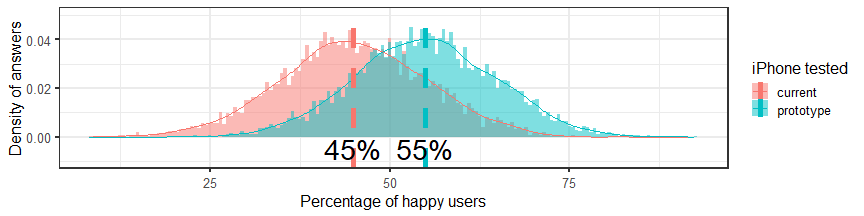

- Conclusion: 45% happy < 55% happy, **let's launch it!**

### Solution 2: Test a sample of iPhone users

- Sample size: 70 users working at Apple
- Method: user test with questionnaire (*“are you happy with the current/prototype iPhone?”* Y/N)
- Results:

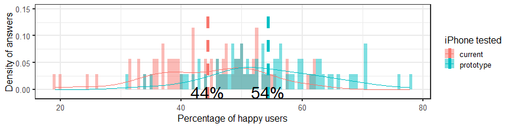

- Conclusion: 44% happy < 54% happy but **is my sample representative of the entire population?**

### Statistical test & statistical significance(1)

All (null hypothesis significance testing) statistical tests respond to **one problem** with **two simple steps**:

- We see apparent difference, but we are not sure if we should believe it's real, because our data are based on samples.
- The two steps:
  - Step 1. Measure the strength of difference in our data.
  - Step 2. Ask ourselves, is this difference large enough to be believed?

A statistical test is required to compare differences between groups smaller than the entire population.

### Statistical test & statistical significance(2)

A statistical test provides an error probability (called **p-value**) which indicates the weakness of the difference.

- The p-value is the probability of having a difference between samples whereas there is no difference in the entire population.

`p-value = probability(Results|No Real Difference)`

If this is low, we'd rather believe that our difference is real than believe it arose from a staggering coincidence.

### What is a low p-value?

By convention an acceptable error probability is **lower than 5%**

If the error probability given by the test is …

- Lower than 5%, **the difference between the samples can be interpreted as representative** of the difference between the entire population.
- Higher than 5%, **the error probability is too high to take the risk** of saying that the difference represents the entire population.

### Thanks for your attention

[figure not shown]

### A bit more time?

```r
df_iphone_current <- data.frame(group = "current", value = rnorm(70,45,10))
df_iphone_prototype <- data.frame(group = "prototype", value = rnorm(70,55,10))

df_iphone <- rbind(df_iphone_current,df_iphone_prototype)

mu <- plyr::ddply(df_iphone, "group", summarise, grp.mean=mean(value))
```

### A bit more time?

```r
df_iphone %>%
  ggplot(aes(x = value, fill = group)) +
  geom_histogram(aes(y = ..density..), alpha=0.5, position='identity', binwidth=0.5) +
  stat_density(aes(color = group),geom="line", position='identity') +
  geom_vline(data=mu, aes(xintercept=grp.mean, color=group),linetype="dashed", size=2)+
  geom_text(data=mu, aes(grp.mean, -0.005, label = paste0(round(grp.mean,0),"%")), size=10) +
  labs(x = "Percentage of happy users", y = "Density of answers", color = "iPhone tested", fill = "iPhone tested") +
  scale_y_continuous(limits = c(-0.01, 0.15)) +
  theme_bw(base_size = 16)
```

### A bit more time?

```r
# results <- df_iphone %>%
#   t.test(value ~ group, data = ., var.equal = TRUE)
tadaatoolbox::tadaa_t.test(data = df_iphone, response = value, group = group, print = "markdown")
```

Table 1: **Two Sample t-test** with alternative hypothesis: \( \mu_1 \neq \mu_2 \)

| Diff | \( \mu_1 \) current | \( \mu_2 \) prototype | t | SE | df | \( CI_{95\%} \) | p | Cohen\'s d | Power |
| --- | --- | --- | --- | --- | --- | --- | --- | --- | --- |
| -9.99 | 44.41 | 54.4 | -6.13 | 1.63 | 138 | (-13.22 - -6.77) | < 0.001 | -1.04 | 1 |